# Aula 1 - Relatório de Experimentação: Severidade de Doenças

## 1. Introdução à Experimentação

Nesta aula, exploramos os conceitos fundamentais de **experimentação agrícola**. O foco inicial foi entender como organizar dados brutos de um ensaio de eficácia de produtos fitossanitários.

A primeira operação realizada foi uma soma simples para testar o ambiente:

```r
a <- 2
b <- 2
a + b
```

```
[1] 4
```

## 2. Materiais e Métodos

O experimento consistiu em avaliar a **severidade** de uma doença em 8 plantas, divididas em dois grupos:

1. **Controle:** Plantas sem tratamento.
2. **Fungicida:** Plantas tratadas com o produto teste.

### Estruturação dos Dados no R

Utilizamos o objeto `data.frame` para tabular as observações de cada planta.

```r
library(tidyverse)

dados <- data.frame(
  planta = seq(1:8),
  tratamento = c("controle", "controle", "controle", "controle",
                 "fungicida", "fungicida", "fungicida", "fungicida"),
  severidade = c(42, 38, 45, 40, 12, 18, 15, 10)
)

knitr::kable(dados) # Gera uma tabela formatada no documento
```

| planta | tratamento | severidade |
| --- | --- | --- |
| 1 | controle | 42 |
| 2 | controle | 38 |
| 3 | controle | 45 |
| 4 | controle | 40 |
| 5 | fungicida | 12 |
| 6 | fungicida | 18 |
| 7 | fungicida | 15 |
| 8 | fungicida | 10 |

## 3. Visualização dos Dados

A visualização é a etapa crítica para entender a dispersão dos dados. Utilizamos o pacote `ggplot2` com as seguintes camadas:

- `geom_jitter`: Para observar cada repetição individualmente sem sobreposição total.
- `stat_summary`: Para destacar a média aritmética de cada tratamento.
- `scale_y_continuous`: Para padronizar a escala de 0 a 50%.

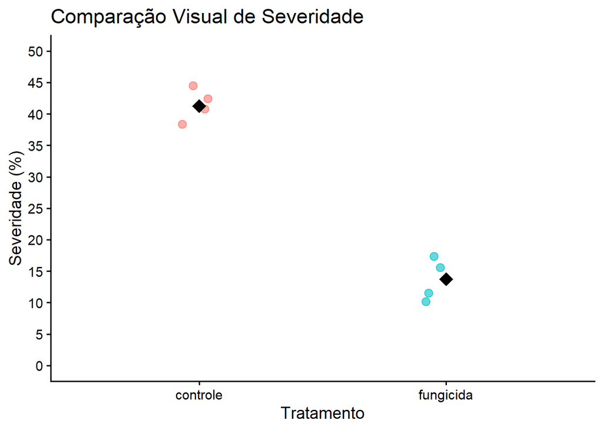

Distribuição da severidade da doença entre os tratamentos.

```r
ggplot(dados, aes(x = tratamento, y = severidade, color = tratamento)) +
  geom_jitter(width = 0.1, size = 3, alpha = 0.6) +
  stat_summary(fun = "mean", geom = "point", shape = 18, size = 5, color = "black") +
  scale_y_continuous(limits = c(0, 50), breaks = seq(0, 50, by = 5)) +
  theme_classic(base_size = 14) +
  labs(
    x = "Tratamento",
    y = "Severidade (%)",
    title = "Comparação Visual de Severidade"
  ) +
  theme(legend.position = "none")
```

## 4. Análise Estatística

Para confirmar se a redução observada no grupo “fungicida” é estatisticamente diferente do “controle”, aplicamos o **Teste t de Student** para amostras independentes.

```r
# Teste t considerando variâncias iguais
resultado <- t.test(severidade ~ tratamento, data = dados, var.equal = TRUE)

resultado
```

```
    Two Sample t-test

data:  severidade by tratamento
t = 11.955, df = 6, p-value = 2.076e-05
alternative hypothesis: true difference in means between group controle and group fungicida is not equal to 0
95 percent confidence interval:
 21.87122 33.12878
sample estimates:
 mean in group controle mean in group fungicida
                  41.25                   13.75
```

*Documento gerado automaticamente para fins acadêmicos.*

[output not shown]